# Practical Machine Learning Project: Prediction Assignment

Marc Vila

3/5/2021

## Overview

This is the report corresponding to the Peer Assessment project from Coursera’s course Practical Machine Learning, as part of the Specialization in Data Science.

The analysis has been carried out with RStudio and the main goal of it is to predict how which 6 participants performed some physical exercises. This behaviour grade corresponds to the *classe* variable in the training set.

Two machine learning algorithms have been developed and applied to the test data in order to quantify its prediction capabilities.

## Background

Using devices such as Jawbone Up, Nike FuelBand, and Fitbit it is now possible to collect a large amount of data about personal activity relatively inexpensively. These type of devices are part of the quantified self movement - a group of enthusiasts who take measurements about themselves regularly to improve their health, to find patterns in their behavior, or because they are tech geeks. One thing that people regularly do is quantify how much of a particular activity they do, but they rarely quantify how well they do it. In this project, your goal will be to use data from accelerometers on the belt, forearm, arm, and dumbell of 6 participants. They were asked to perform barbell lifts correctly and incorrectly in 5 different ways.

More information is available from the website here: http://groupware.les.inf.puc-rio.br/har See the section on the Weight Lifting Exercise Dataset).

## 1. Data Sets and Exploratory Analysis

### 1.1. Data Sets

The training data for this project are available here:

https://d396qusza40orc.cloudfront.net/predmachlearn/pml-training.csv

The test data are available here:

https://d396qusza40orc.cloudfront.net/predmachlearn/pml-testing.csv

The data for this project come from http://groupware.les.inf.puc-rio.br/har

Velloso, E.; Bulling, A.; Gellersen, H.; Ugulino, W.; Fuks, H. “Qualitative Activity Recognition of Weight Lifting Exercises. Proceedings of 4th International Conference in Cooperation with SIGCHI (Augmented Human ’13)”. Stuttgart, Germany: ACM SIGCHI, 2013.

### 1.2. Basic Exploratory data analysis

```r
## Libraries

library(caret)
```

```r
library(rpart)
library(rpart.plot)
library(corrplot)
library(ggplot2)

## Loading the files that contain the data
trainingRaw <- read.csv("pml-training.csv", na.strings = c("NA", "#DIV/0!", ""))
testingRaw <- read.csv("pml-testing.csv", na.strings = c("NA", "#DIV/0!", ""))
```

**Data Preprocessing and Cleaning**

```r
dim(trainingRaw)
```

```
## [1] 19622   160
```

```r
dim(testingRaw)
```

```
## [1]  20 160
```

```r
## Data preprocessing
classe <- trainingRaw$classe

## The 7 first columns are meaningless for our analysis purposes
trainingRaw <- trainingRaw[, 8:160]
testingRaw  <- testingRaw[, 8:160]

## Cleaning those column with all NA values
training <- trainingRaw[, colSums(is.na(trainingRaw)) == 0]
testing <- testingRaw[, colSums(is.na(testingRaw)) == 0]

## Adding again classe field to our data frame
training$classe <- classe
```

**Exploratory Analysis**

```r
dim(training)
```

```
## [1] 19622    53
```

```r
dim(testing)
```

```
## [1] 20 53
```

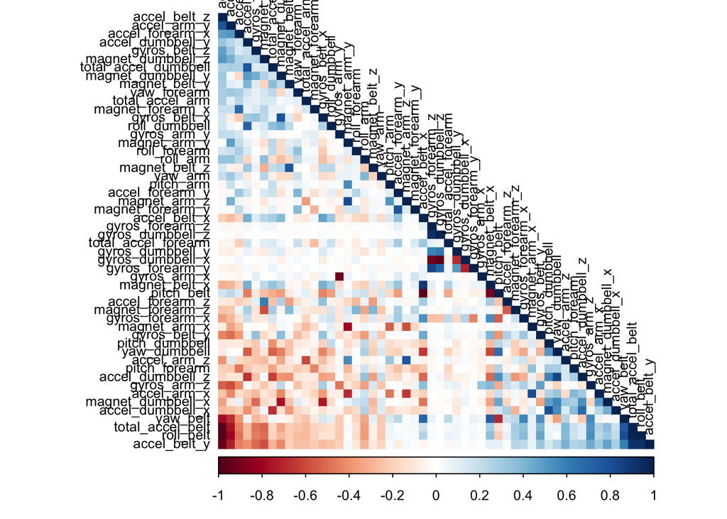

```r
##Correlation Matrix

corrMatrix <- cor(training[, -length(names(training))])
corrplot(corrMatrix, order = "FPC", method = "color", type = "lower", tl.cex = 0.8, tl.col = rgb(0, 0, 0))
```

The correlation between the variables is relatively low, only those that are referred to the same position in diferent axis of measurement have higher correlation values.

## 2. Random Forest and Gradient Boosting Machine models

### 2.1. Reproducible split of our data into 75% of Training Set and 25% Validation Set

```r
## Reproducible split of our data into 75% of Training Set and 35% Validation Set
set.seed(1234567)
inTrain <- createDataPartition(y=training$classe, p=0.75, list=FALSE)
trainData  <- training[inTrain,]
testData  <- training[-inTrain,]
```

### 2.2. Random Forest Model

```r
## Data Modeling using Random Forest algorithm with resampling method of 8 folds CV

controlRF <- trainControl(method="cv", number = 8)
modelRF <- train(classe ~ ., data=trainData, method="rf", trControl=controlRF, ntree=201)
modelRF
```

```
## Random Forest
##
## 14718 samples
##    52 predictor
##     5 classes: 'A', 'B', 'C', 'D', 'E'
##
## No pre-processing
## Resampling: Cross-Validated (8 fold)
## Summary of sample sizes: 12879, 12878, 12877, 12879, 12879, 12877, ...
## Resampling results across tuning parameters:
##
##   mtry  Accuracy   Kappa
##    2    0.9920510  0.9899436
##   27    0.9923232  0.9902888
##   52    0.9885181  0.9854749
##
## Accuracy was used to select the optimal model using the largest value.
## The final value used for the model was mtry = 27.
```

**Performance of our RF model on the validation data set**

```r
predictRF <- predict(modelRF, testData)
CMRF <- confusionMatrix(factor(testData$classe), predictRF)
```

### 2.3. GBM Model

```r
## Data Modeling using Gradient Boosting Machine algorithm with resampling method of 8 folds CV

controlGBM <- trainControl(method = "repeatedcv", number = 8, repeats = 1)
modelGBM  <- train(classe ~ ., data=trainData, method = "gbm", trControl = controlGBM, verbose = FALSE)
modelGBM
```

```
## Stochastic Gradient Boosting
##
## 14718 samples
##    52 predictor
##     5 classes: 'A', 'B', 'C', 'D', 'E'
##
## No pre-processing
## Resampling: Cross-Validated (8 fold, repeated 1 times)
## Summary of sample sizes: 12879, 12879, 12878, 12878, 12878, 12879, ...
## Resampling results across tuning parameters:
##
##   interaction.depth  n.trees  Accuracy   Kappa
##   1                   50      0.7547872  0.6891433
##   1                  100      0.8196747  0.7718689
##   1                  150      0.8539193  0.8151304
##   2                   50      0.8560253  0.8175895
##   2                  100      0.9086129  0.8843633
##   2                  150      0.9321219  0.9141105
##   3                   50      0.8965867  0.8690855
##   3                  100      0.9419071  0.9265084
##   3                  150      0.9611349  0.9508301
##
## Tuning parameter 'shrinkage' was held constant at a value of 0.1
##
## Tuning parameter 'n.minobsinnode' was held constant at a value of 10
## Accuracy was used to select the optimal model using the largest value.
## The final values used for the model were n.trees = 150, interaction.depth =
##  3, shrinkage = 0.1 and n.minobsinnode = 10.
```

**Performance of our GBM model on the validation data set**

```r
predictGBM <- predict(modelGBM, testData)
CMGBM <- confusionMatrix(factor(testData$classe), predictGBM)
```

### 2.4. comparison of both Models

**Random Forest Model**

```r
CMRF
```

```
## Confusion Matrix and Statistics
##
##           Reference
## Prediction    A    B    C    D    E
##          A 1394    0    1    0    0
##          B   11  937    1    0    0
##          C    0    0  850    5    0
##          D    1    1   18  784    0
##          E    0    1    1    4  895
##
## Overall Statistics
##
##                Accuracy : 0.991
##                  95% CI : (0.988, 0.9935)
##     No Information Rate : 0.2867
##     P-Value [Acc > NIR] : < 2.2e-16
##
##                   Kappa : 0.9886
##
##  Mcnemar's Test P-Value : NA
##
## Statistics by Class:
##
##                      Class: A Class: B Class: C Class: D Class: E
## Sensitivity            0.9915   0.9979   0.9759   0.9887   1.0000
## Specificity            0.9997   0.9970   0.9988   0.9951   0.9985
## Pos Pred Value         0.9993   0.9874   0.9942   0.9751   0.9933
## Neg Pred Value         0.9966   0.9995   0.9948   0.9978   1.0000
## Prevalence             0.2867   0.1915   0.1776   0.1617   0.1825
## Detection Rate         0.2843   0.1911   0.1733   0.1599   0.1825
## Detection Prevalence   0.2845   0.1935   0.1743   0.1639   0.1837
## Balanced Accuracy      0.9956   0.9974   0.9873   0.9919   0.9993
```

```r
CMRF$overall
```

```
##       Accuracy          Kappa  AccuracyLower  AccuracyUpper   AccuracyNull
##      0.9910277      0.9886482      0.9879737      0.9934734      0.2867047
## AccuracyPValue  McnemarPValue
##      0.0000000            NaN
```

**GBM Model**

```r
CMGBM
```

```
## Confusion Matrix and Statistics
##
##           Reference
## Prediction    A    B    C    D    E
##          A 1373   16    4    2    0
##          B   34  893   22    0    0
##          C    0   27  820    7    1
##          D    1    7   28  761    7
##          E    1    8    7   14  871
##
## Overall Statistics
##
##                Accuracy : 0.9621
##                  95% CI : (0.9563, 0.9672)
##     No Information Rate : 0.2873
##     P-Value [Acc > NIR] : < 2.2e-16
##
##                   Kappa : 0.952
##
##  Mcnemar's Test P-Value : 1.045e-06
##
## Statistics by Class:
##
##                      Class: A Class: B Class: C Class: D Class: E
## Sensitivity            0.9744   0.9390   0.9308   0.9707   0.9909
## Specificity            0.9937   0.9858   0.9913   0.9896   0.9925
## Pos Pred Value         0.9842   0.9410   0.9591   0.9465   0.9667
## Neg Pred Value         0.9897   0.9853   0.9849   0.9944   0.9980
## Prevalence             0.2873   0.1939   0.1796   0.1599   0.1792
## Detection Rate         0.2800   0.1821   0.1672   0.1552   0.1776
## Detection Prevalence   0.2845   0.1935   0.1743   0.1639   0.1837
## Balanced Accuracy      0.9841   0.9624   0.9610   0.9801   0.9917
```

```r
CMGBM$overall
```

```
##       Accuracy          Kappa  AccuracyLower  AccuracyUpper   AccuracyNull
##   9.620718e-01   9.520065e-01   9.563413e-01   9.672434e-01   2.873165e-01
## AccuracyPValue  McnemarPValue
##   0.000000e+00   1.045436e-06
```

The best accuracy corresponds to the Random Forest model **0.991** compared to GBM model which has an accuracy of **0.961**.

### 3.1. Application of the RF model on the Testing Data.

```r
RFprediction <- predict(modelRF, testing)
RFprediction
```

```
##  [1] B A B A A E D B A A B C B A E E A B B B
## Levels: A B C D E
```

### 3.2. Application of the GBM model on the Testing Data.

```r
GBMprediction <- predict(modelGBM, testing)
GBMprediction
```

```
##  [1] B A B A A E D B A A B C B A E E A B B B
## Levels: A B C D E
```